# STAT/MATH 495: Problem Set 09

Brendan Seto

2017-11-07

# Question 1: Run k-means

```r
observations_1 <- read_csv("data/observations_1.csv")
observations_2 <- read_csv("data/observations_2.csv")

# Set observations to be one of two datasets
observations <- observations_2

# Fit model for k=2
k <- 2
k_means_results <- kmeans(observations, centers=k)
clusters <- k_means_results$cluster
cluster_centers <- k_means_results$centers

# Add cluster results to observations. Note we convert to factor since cluster
# ID's should be treated as categorical
observations$cluster <- as.factor(clusters)

# Add cluster ID's to cluster_centers
cluster_centers <- cluster_centers %>%
  as_tibble() %>%
  mutate(cluster=as.factor(1:k))

p2 <-ggplot(NULL, aes(x=x1, y=x2, col=cluster)) +
  geom_point(data=observations) +
  geom_point(data=cluster_centers, size=5) +
  labs(list(title = "Data from Observations_2"))+
  guides(col=FALSE)
```

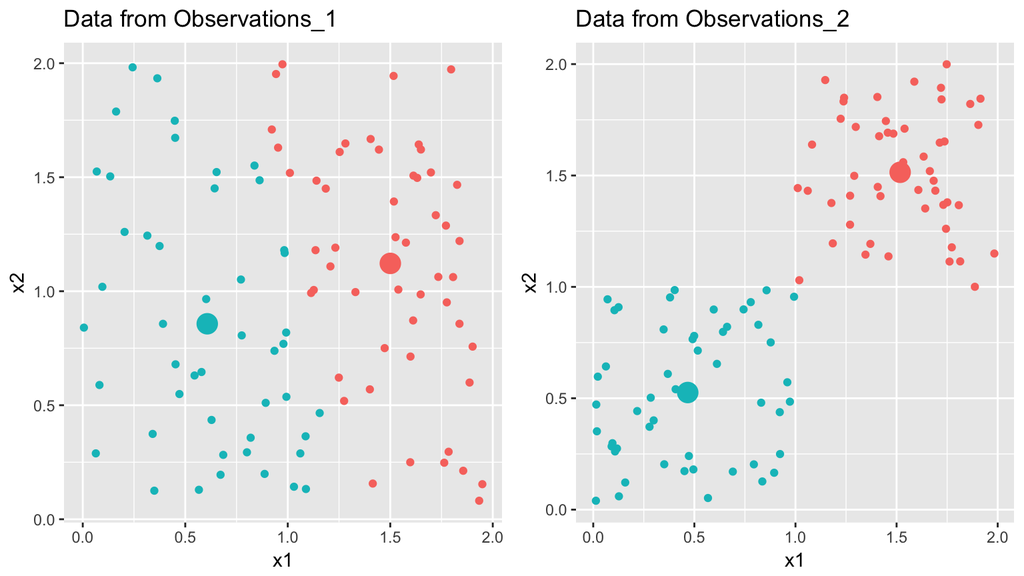

```r
# Set observations to be one of two datasets
observations <- observations_1

# Fit model for k=2
k <- 2
k_means_results <- kmeans(observations, centers=k)
clusters <- k_means_results$cluster
cluster_centers <- k_means_results$centers

# Add cluster results to observations. Note we convert to factor since cluster
# ID's should be treated as categorical
observations$cluster <- as.factor(clusters)

# Add cluster ID's to cluster_centers
cluster_centers <- cluster_centers %>%
  as_tibble() %>%
  mutate(cluster=as.factor(1:k))

p1 <- ggplot(NULL, aes(x=x1, y=x2, col=cluster)) +
  geom_point(data=observations) +
  geom_point(data=cluster_centers, size=5) +
  labs(list(title = "Data from Observations_1"))+
  guides(col=FALSE)

grid.arrange(p1,p2, ncol=2)
```

## Answers:

### 1. Run KMC 10 times on `observations_1` and comment on the consistency of the results.

For the purposes of this assignment, I will only be looking at the location of the cluster centers (i hope this is right).

```r
kms1 <- function(data){
  # Set observations to be one of two datasets
  observations <- data

  # Fit model for k=2
  k <- 2
  k_means_results <- kmeans(observations, centers=k)
  clusters <- k_means_results$cluster
  cluster_centers <- k_means_results$centers

  # Add cluster results to observations. Note we convert to factor since cluster
  # ID's should be treated as categorical
  observations$cluster <- as.factor(clusters)

  # Add cluster ID's to cluster_centers
  cluster_centers <- cluster_centers %>%
    as_tibble() %>%
    arrange(x1,x2) %>%
    mutate(cluster=as.factor(1:k))

  return(cluster_centers)
}

prob1 <- do(10)*kms1(observations_1)

prob1 %>% group_by(cluster) %>%
  summarise(mean_x1 = mean(x1), mean_x2 = mean(x2), sd_1 = sd(x1), sd_x2 = sd(x2))
```

| cluster | mean_x1 | mean_x2 | sd_1 | sd_x2 |
| --- | --- | --- | --- | --- |
| 1 | 0.8307541 | 0.6108661 | 0.1832016 | 0.1738621 |
| 2 | 1.2763071 | 1.3092322 | 0.1633873 | 0.1381631 |

### 2. Speculate on the root cause of any consistency or inconsistency in the results.

I don’t think there is a “natural” grouping in this data. As we can see in the plots above, there is a fairly uniform distribution. I do not expect distinct clusters to come up every time.

### 3. Run KMC 10 times on `observations_2` and comment on the consistentcy of the results.

```r
prob2 <- do(10)*kms1(observations_2)

prob2 %>% group_by(cluster) %>%
  summarise(mean_x1 = mean(x1), mean_x2 = mean(x2), sd_1 = sd(x1), sd_x2 = sd(x2))
```

| cluster | mean_x1 | mean_x2 | sd_1 | sd_x2 |
| --- | --- | --- | --- | --- |
| 1 | 0.4671824 | 0.525768 | 0 | 0 |
| 2 | 1.5176316 | 1.514356 | 0 | 0 |

Here there is no standard deviation, the same clusters appear every time. This leads me to believe that there is a very distinct pair of clusters that are so strong, they appear over and over again.

### 4. Speculate on the root cause of any consistency or inconsistency in the results.

Look at the graph. There are clearly two distinct groupings. I bet Albert simulated the data from these two points, but even then it’s striking that they are exactly the same every time…

# Bonus question: Code your own

Read ISLR page 388 Algorithm 10.1 and implement k-means clustering from scratch. Don’t worry about doing it for general $k$; keep it simple and do it for $k=2$ specifically. Apply it to `observations_2` from above.

```r
# Hint:
library(proxy)

A <- data_frame(
  x1 = c(0, 0.5, 0.75, 1),
  x2 = c(0, 0.5, 0.75, 1)
  )

B <- data_frame(
  x1 = c(1, 0),
  x2 = c(1, 0)
  )

kms2_pre <- function(data, center1, center2){
  A <- data
  B <- data_frame(
    x1 = center1,
    x2 = center2
  )
  distance_matrix <- proxy::dist(x=A, y=B)
  distance_matrix
  data <- data %>% mutate(cluster = apply(distance_matrix, 1, which.min)) %>%
    group_by(cluster) %>%
    summarise(x1 = mean(x1), x2 = mean(x2))

  return(data)
}

for(i in seq(1:10)){
  B <- kms2_pre(observations_2, B$x1, B$x2) %>% select(x1,x2)
}

B %>% arrange(x1) %>% cbind(prob2 %>% group_by(cluster) %>% summarise(P2_x1 = mean(x1), P2_x2 = mean(x2)))
```

| x1 | x2 | cluster | P2_x1 | P2_x2 |
| --- | --- | --- | --- | --- |
| 0.4671824 | 0.525768 | 1 | 0.4671824 | 0.525768 |
| 1.5176316 | 1.514356 | 2 | 1.5176316 | 1.514356 |

Yay! Got same clusters!